# Analysis of Covid19 Cases in USA and Nigeria

# **Forecasting of Covid19 Cases in Nigeria**

```r
M <- prophet(df)
```

```
## Disabling yearly seasonality. Run prophet with yearly.seasonality=TRUE to override this.
```

```
## Disabling daily seasonality. Run prophet with daily.seasonality=TRUE to override this.
```

# **Prediction**

|  | ds | trend | additive_terms | additive_terms_lower | additive_terms_upper | weekly | weekly_lower | weekly_upper | multiplicative_terms | multiplicative_terms_lower | multiplicative_terms_upper | yhat_lower | yhat_upper | trend_lower | trend_upper | yhat |
| --- | --- | --- | --- | --- | --- | --- | --- | --- | --- | --- | --- | --- | --- | --- | --- | --- |
| 1 | 2020-01-22T00:00:00Z | -412.9077525131499 | -82.12578001434953 | -82.12578001434953 | -82.12578001434953 | -82.12578001434953 | -82.12578001434953 | -82.12578001434953 | 0 | 0 | 0 | -4273.765253804038 | 3361.51373000633 | -412.9077525131499 | -412.9077525131499 | -495.0335325274994 |
| 2 | 2020-01-23T00:00:00Z | -403.1021288202862 | -27.40979917150963 | -27.40979917150963 | -27.40979917150963 | -27.40979917150963 | -27.40979917150963 | -27.40979917150963 | 0 | 0 | 0 | -3978.541384199469 | 3455.081190302561 | -403.1021288202862 | -403.1021288202862 | -430.5119279917959 |
| 3 | 2020-01-24T00:00:00Z | -393.2965051274226 | 32.41854339842387 | 32.41854339842387 | 32.41854339842387 | 32.41854339842387 | 32.41854339842387 | 32.41854339842387 | 0 | 0 | 0 | -4152.390166959905 | 3365.970806743365 | -393.2965051274226 | -393.2965051274226 | -360.8779617289987 |
| 4 | 2020-01-25T00:00:00Z | -383.4908814345589 | 98.94976716414727 | 98.94976716414727 | 98.94976716414727 | 98.94976716414727 | 98.94976716414727 | 98.94976716414727 | 0 | 0 | 0 | -4099.499780050322 | 3558.770148510433 | -383.4908814345589 | -383.4908814345589 | -284.5411142704116 |
| 5 | 2020-01-26T00:00:00Z | -373.6852577416952 | 67.62319306982505 | 67.62319306982505 | 67.62319306982505 | 67.62319306982505 | 67.62319306982505 | 67.62319306982505 | 0 | 0 | 0 | -4162.09279981878 | 3558.339669555553 | -373.6852577416952 | -373.6852577416952 | -306.0620646718702 |
| 6 | 2020-01-27T00:00:00Z | -363.8796340488316 | 57.73899505348374 | 57.73899505348374 | 57.73899505348374 | 57.73899505348374 | 57.73899505348374 | 57.73899505348374 | 0 | 0 | 0 | -4238.391771130595 | 3780.998908026952 | -363.8796340488316 | -363.8796340488316 | -306.1406389953478 |
| 7 | 2020-01-28T00:00:00Z | -354.0740103559679 | -147.1949194997639 | -147.1949194997639 | -147.1949194997639 | -147.1949194997639 | -147.1949194997639 | -147.1949194997639 | 0 | 0 | 0 | -4215.239978870699 | 3352.472065766683 | -354.0740103559679 | -354.0740103559679 | -501.2689298557318 |
| 8 | 2020-01-29T00:00:00Z | -344.2683866631042 | -82.12578001455607 | -82.12578001455607 | -82.12578001455607 | -82.12578001455607 | -82.12578001455607 | -82.12578001455607 | 0 | 0 | 0 | -4296.182946612392 | 3271.692164052224 | -344.2683866631042 | -344.2683866631042 | -426.3941666776603 |
| 9 | 2020-01-30T00:00:00Z | -334.4627629702406 | -27.40979917166142 | -27.40979917166142 | -27.40979917166142 | -27.40979917166142 | -27.40979917166142 | -27.40979917166142 | 0 | 0 | 0 | -3960.781000474949 | 3459.113816729892 | -334.4627629702406 | -334.4627629702406 | -361.872562141902 |
| 10 | 2020-01-31T00:00:00Z | -324.6571392773769 | 32.41854339796253 | 32.41854339796253 | 32.41854339796253 | 32.41854339796253 | 32.41854339796253 | 32.41854339796253 | 0 | 0 | 0 | -4477.733806974575 | 3643.864472276253 | -324.6571392773769 | -324.6571392773769 | -292.2385958794143 |

[output cut: 20 more lines]

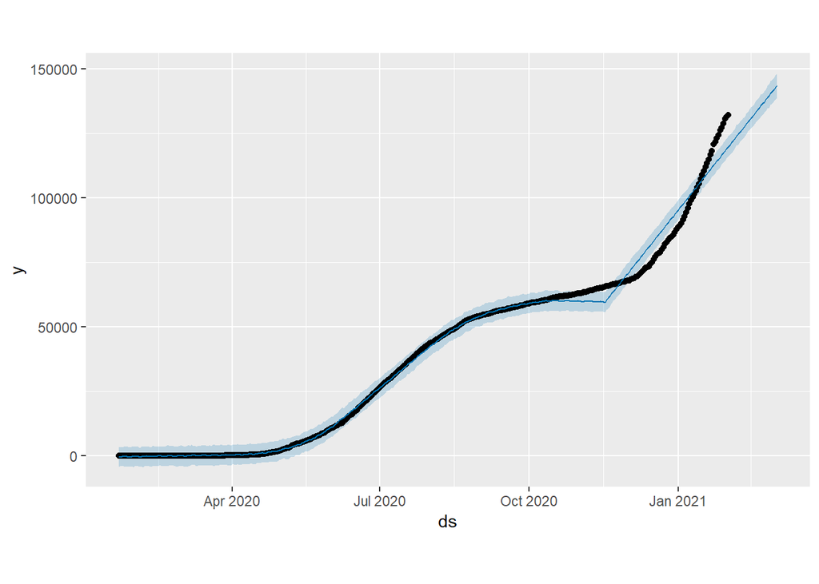

[interactive chart not shown]

# **Findings**

On 12th July 2020, the actual covid19 cases was about 32558 Covid19 cases and the predicted value was about 32127 cases. On the 20th August 2020, actual covid19 cases in Nigeria was about 50964 cases and the predicted was about 50597 cases. AS at 29th October 2020, the actual covid19 case was about 62521 cases and the predicted value was about 59888 cases.On the 23rd February 2021,the predicted covid19 cases in Nigeria was about 137066. In the line graph you also notice a confidence band which means that the predictions can be slightly higher or lower.

# **Forecast Components**

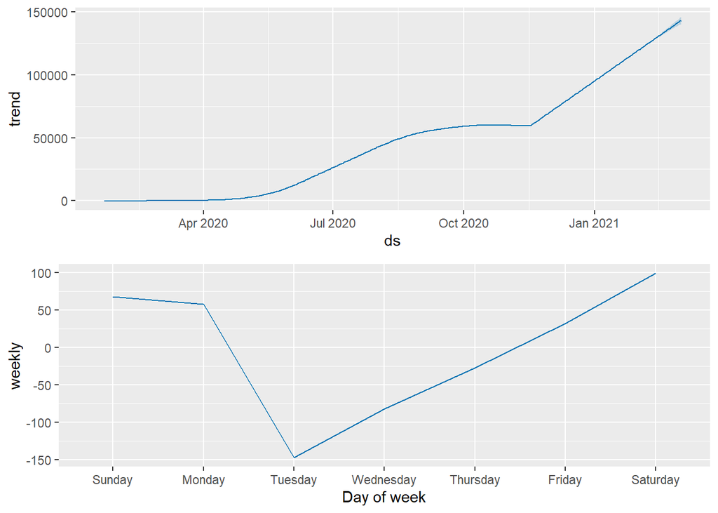

# **Model Performance**

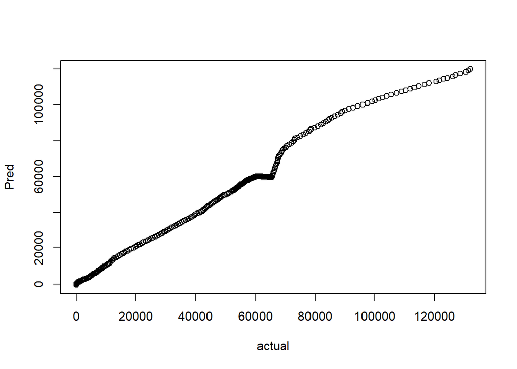

# **Estimation**

```
##
## Call:
## lm(formula = Pred ~ actual)
##
## Residuals:
##      Min       1Q   Median       3Q      Max
## -11364.2   -683.7   -251.5    425.7   8200.0
##
## Coefficients:
##              Estimate Std. Error t value Pr(>|t|)
## (Intercept) 3.751e+02  2.322e+02   1.616    0.107
## actual      9.904e-01  4.425e-03 223.804   <2e-16 ***
## ---
## Signif. codes:  0 '***' 0.001 '**' 0.01 '*' 0.05 '.' 0.1 ' ' 1
##
## Residual standard error: 3003 on 375 degrees of freedom
## Multiple R-squared:  0.9926, Adjusted R-squared:  0.9925
## F-statistic: 5.009e+04 on 1 and 375 DF,  p-value: < 2.2e-16
```